# Datos cualitativos 7 - Ejemplo final

Moises

28/2/2020

## Un ejemplo final

Vamos a llevar a cabo un análisis completo de un ejemplo con lo que hemos aprendido en esta lección y aprovecharemos para aprender algo nuevo.

El objeto de datos HairEyeColor que lleva predefinido R es una tabla de frecuencias absolutas de tres variables cualitativas: color de cabello (Hair), color de los ojos (Eye) y sexo (Sex).

Vamos a extraer de esta tabla una tabla bidimensional de frecuencias absolutas de las variables Eye y Hair, sin distinguir según el sexo. La manera más sencilla de obtener esta tabla es sumando las subtablas de frecuencias para hombres y mujeres, y aplicando as.table() al resultado para transformarlo en una table por si no lo es.

Vamos a traducir al castellano los nombres de las variables de esta tabla y de sus niveles. Esto lo podemos llevar a cabo en un solo paso con la función dimnames() que ya usamos sobre data frames. El resultado de aplicar esta función a una table es una list cuyas componentes son los niveles de cada variable.

## Ejercicio 1

Proceso para juntar el color de ojos y pelo sin tener en cuenta el sexo, osea llevarla de tridimensional a bidimensional

```r
HEC = HairEyeColor #Guardamos HairEyeColor en una variable

dimnames(HEC) #Aqui se puede ver cada variable con sus niveles
```

```
## $Hair
## [1] "Black" "Brown" "Red"   "Blond"
##
## $Eye
## [1] "Brown" "Blue"  "Hazel" "Green"
##
## $Sex
## [1] "Male"   "Female"
```

```r
male_table = HEC[,,"Male"] #Filtro solo los datos de los hombres y los guardo
female_table = HEC[,,"Female"] #Filtro solo los datos de las mujeres y los guardo

HEC_table = male_table+female_table #Junto las dos tablas y listo

HEC_table
```

```
##        Eye
## Hair    Brown Blue Hazel Green
##   Black    68   20    15     5
##   Brown   119   84    54    29
##   Red      26   17    14    14
##   Blond     7   94    10    16
```

## Ejercicio 2.

Redefinid dicha list para tener los niveles de los factores en castellano

```r
dimnames(HEC_table) #Con dimnames podremos generar una lista de HEC_table dimnames con sus factores y niveles
```

```
## $Hair
## [1] "Black" "Brown" "Red"   "Blond"
##
## $Eye
## [1] "Brown" "Blue"  "Hazel" "Green"
```

```r
dimnames(HEC_table) = list(
   Pelo = c("Negro","Marron","Pelirrojo","Rubio"),
  Ojos = c("Marrones","Azules","Cremas","Verdes")
) #Por lo que podemos redefinir dicha lista con los nuevos valores

dimnames(HEC_table) # Y listo
```

```
## $Pelo
## [1] "Negro"     "Marron"    "Pelirrojo" "Rubio"
##
## $Ojos
## [1] "Marrones" "Azules"   "Cremas"   "Verdes"
```

## Ejercicio 3

A continuación, vamos a calcular el número total de individuos representados en esta tabla:

```r
sum(HEC_table) #Numero total de individuos, esto se puede hacer con este dataframe porque es un table y los tables don dataframes numericos
```

```
## [1] 592
```

## Ejercicio 4

Las tablas de frecuencias absolutas y relativas de cada variable,

```r
colSums(HEC_table) #Sumando todas las columnas tenemos la cantidad de individuos por ojos
```

```
## Marrones   Azules   Cremas   Verdes
##      220      215       93       64
```

```r
rowSums(HEC_table) #Sumando todas las filas tenemos la cantidad de individuos por pelo
```

```
##     Negro    Marron Pelirrojo     Rubio
##       108       286        71       127
```

```r
prop.table(colSums(HEC_table)) #Para obtener la frecuencia relativa global
```

```
##  Marrones    Azules    Cremas    Verdes
## 0.3716216 0.3631757 0.1570946 0.1081081
```

```r
prop.table(rowSums(HEC_table)) #Para obtener la frecuencia relativa global
```

```
##     Negro    Marron Pelirrojo     Rubio
## 0.1824324 0.4831081 0.1199324 0.2145270
```

## Ejercicio 5

Representaremos estas últimas en sendos diagramas de barras.

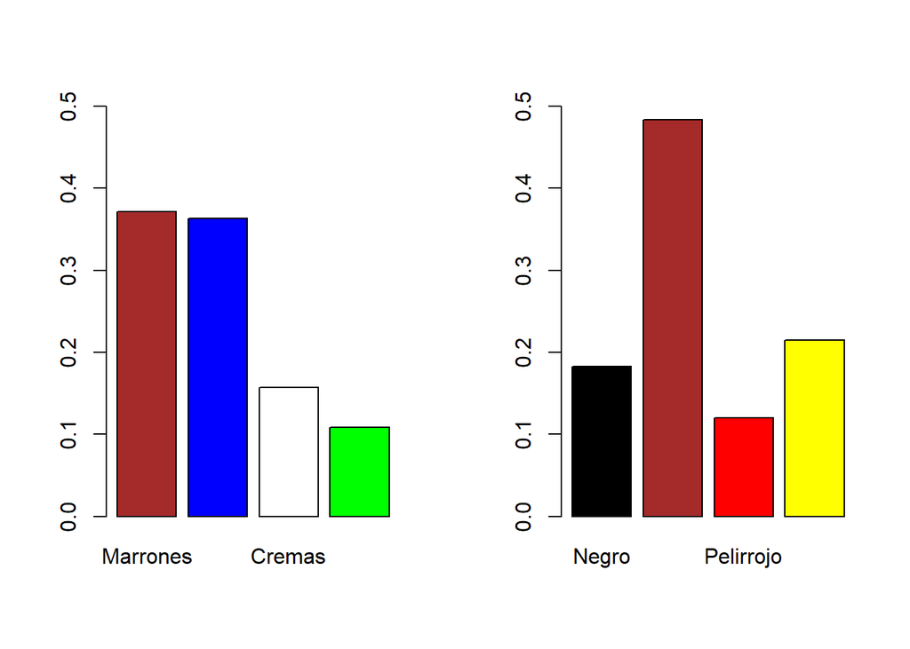

```r
par(mfrow=c(1,2)) #Para poder poner 2 o mas graficos uno al lado del otro
barplot(prop.table(colSums(HEC_table)), col=c("brown","blue","white","green"), ylim=c(0,0.5))
barplot(prop.table(rowSums(HEC_table)), col=c("black","brown","red","yellow"),ylim=c(0,0.5))
```

## Ejercicio 6

En el diagrama anterior vemos que el color dominante de cabellos es el castaño, mientras que en el color de ojos el marrón y el azul están prácticamente empatados. Pasamos ahora a calcular las tablas de frecuencias relativas y dibujar los dos diagramas de barras de las frecuencias relativas marginales.

```r
round(prop.table(HEC_table),3) # Frecuencia relativa global
```

```
##            Ojos
## Pelo        Marrones Azules Cremas Verdes
##   Negro        0.115  0.034  0.025  0.008
##   Marron       0.201  0.142  0.091  0.049
##   Pelirrojo    0.044  0.029  0.024  0.024
##   Rubio        0.012  0.159  0.017  0.027
```

```r
round(prop.table(HEC_table, margin=1),3) # Frecuencia relativa marginal por ojos
```

```
##            Ojos
## Pelo        Marrones Azules Cremas Verdes
##   Negro        0.630  0.185  0.139  0.046
##   Marron       0.416  0.294  0.189  0.101
##   Pelirrojo    0.366  0.239  0.197  0.197
##   Rubio        0.055  0.740  0.079  0.126
```

```r
round(prop.table(HEC_table, margin=2),3) # Frecuencia relativa marginal por pelo
```

```
##            Ojos
## Pelo        Marrones Azules Cremas Verdes
##   Negro        0.309  0.093  0.161  0.078
##   Marron       0.541  0.391  0.581  0.453
##   Pelirrojo    0.118  0.079  0.151  0.219
##   Rubio        0.032  0.437  0.108  0.250
```

## Ejercicio 7

Haz 2 graficos con las frecuencias relativas marginales con colores, titulo y leyendas

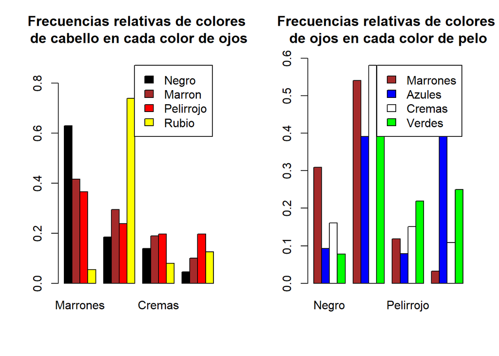

```r
par(mfrow=c(1,2))
barplot(round(prop.table(HEC_table, margin=1),3), col=c("black","brown","red","yellow"),ylim=c(0,0.90),beside=TRUE,legend.text = TRUE, main="Frecuencias relativas de colores \nde cabello en cada color de ojos")

barplot(round(t(prop.table(HEC_table, margin=2)),3), col=c("brown","blue","white","green"),ylim=c(0,0.60),beside=TRUE,legend.text = TRUE, main="Frecuencias relativas de colores \nde ojos en cada color de pelo") #IMPORTANTE: En este segundo grafico hay que transponer la tabla para que las filas y columnas se inviertan ya que la leyenda se toma de las filas NO de las columnas
```

## Ejercicio 8

Instalad y cargad el paquete MASS. Encontraréis una tabla de datos llamada birthwt sobre factores que pueden incidir en el peso de los niños al nacer. Con str() y head(), explorad la estructura, y con help(), mirad el significado de cada variable.

1- Calculad una tabla de frecuencias relativas marginales de los pares (raza de la madre, peso inferior a 2.5 kg o no) que permita ver si la raza de la madre influye en el peso del bebé. Dibujad un diagrama de mosaico de esta tabla.

2- Dibujad un diagrama bidimensional de barras, con las barras organizadas en bloques, que permita visualizar esta información. Poned nombres adecuados a los bloques, colores a las barras, y añadid una leyenda que explique qué representa cada barra. ¿Se puede obtener alguna conclusión de esta tabla y de este diagrama de barras?

3- Repetid los dos puntos anteriores para los pares (madre fumadora o no, peso inferior a 2.5 kg o no) y para los pares (madre hipertensa o no, peso inferior a 2.5 kg o no).

4- Calculad una tabla de frecuencias relativas marginales de las ternas (raza de la madre, madre fumadora o no, peso inferior a 2.5 kg o no) que permita ver si la raza de la madre y su condición de fumadora o no fumadora influyen en el peso del bebé. Dibujad un diagrama de mosaico de esta tabla.